# Nanofish: Sensory-motor function

# Set up environment

## Load data

### Adjust classes and transformations

```
'data.frame':   467 obs. of  30 variables:
 $ StudyID             : Factor w/ 59 levels "2","3","4","5",..: 40 40 50 50 50 50 16 16 16 7 ...
 $ StudyCluster        : Factor w/ 34 levels "1","2","3","5",..: 4 4 5 5 5 5 4 4 4 18 ...
 $ Study               : Factor w/ 59 levels "Ašmonaitė et al., 2020",..: 1 1 2 2 2 2 3 3 3 4 ...
 $ Year                : int  2020 2020 2018 2018 2018 2018 2020 2020 2020 2019 ...
 $ EScluster           : Factor w/ 101 levels "1","2","3","4",..: 1 1 2 2 2 2 3 3 3 4 ...
 $ AdministrationRoute : Factor w/ 6 levels "Food","Injection",..: 1 1 4 4 4 4 1 1 1 4 ...
 $ Concentration_mg_L  : num  NA NA 0.26 0.69 0.26 0.69 NA NA NA 20 ...
 $ ParticleMaterial    : Factor w/ 6 levels "Aminoplast","PE",..: 5 2 1 1 1 1 2 2 2 5 ...
 $ Species             : Factor w/ 20 levels "Argyrosomus regius",..: 9 9 8 8 8 8 9 9 9 7 ...
 $ ParticleShape       : Factor w/ 4 levels "Irregular","Sphere",..: 2 2 2 2 2 2 2 2 2 2 ...
 $ Sex                 : Factor w/ 4 levels "F","F:M","M",..: 4 4 4 4 4 4 4 4 4 NA ...
 $ DevelopmentalStage  : Factor w/ 5 levels "Embrio","Larva",..: 4 4 4 4 4 4 4 4 4 2 ...
 $ ExposureDurationCat : Factor w/ 3 levels "15 days +","5-15 days",..: 2 2 3 3 3 3 1 1 1 3 ...
 $ ExposureDurationDays: int  14 14 4 4 4 4 28 28 28 2 ...
```

[output cut: 16 more lines]

### Calculate Effect Size

```r
df_original <- metafor::escalc(measure = "SMD", n1i = n_treat, n2i = n_ctrl, m1i = mean_treat,
    m2i = mean_ctrl, sd1i = STD_treat, sd2i = STD_ctrl, data = df_original, vtype = "UB")
write.csv(df_original, file = "mvMetaAnalysis_SMDs.csv")
```

### Create variables

```r
outcome <- as.character(outcomeslist[[n_outcome]])

mRF <- list()  # random effects formula investigation models
mRE <- list()  # random effects multilevel models
mMR <- list()  # multilevel metaregression models

colormap <- c(Embrio = "khaki", Larva = "lightgreen", Juvenile = "lightskyblue",
    Adult = "salmon", Unclear = "plum", ExposureDurationDays = "cornflowerblue",
    ParticleSizeMean = "chartreuse4", Concentration_mg_L = "#fa0079ff", Aminoplast = "chocolate4",
    LDPE = "#2200faff", PE = "#0089faff", PET = "#00faedff", PLA = "#00fa29ff", PS = "#faf200ff",
    PVC = "#fa9a00ff", `Publication year` = "black", Variance = "navyblue")
```

### Select outcome

```
[1] "Sensory-motor function: Distance"
```

|  | StudyID | StudyCluster | Study | Year | EScluster | AdministrationRoute | Concentration_mg_L | ParticleMaterial | Species | ParticleShape | Sex | DevelopmentalStage | ExposureDurationCat | ExposureDurationDays | ParticleSizeRange | ParticleSizeMean | ParticleSizeCat | Outcome | OutcomeCategory | Test_or_Assay | OutcomeVariable | Group | n_of_groups | n_ctrl | mean_ctrl | STD_ctrl | n_treat | mean_treat | STD_treat | … |
| --- | --- | --- | --- | --- | --- | --- | --- | --- | --- | --- | --- | --- | --- | --- | --- | --- | --- | --- | --- | --- | --- | --- | --- | --- | --- | --- | --- | --- | --- | --- |
| 10 | 13 | 23 | Brun et al., 2019 | 2019 | 4 | Water: Semi-static system | 20 | PS | Danio rerio | Sphere |  | Larva | up to 96h | 2 | 0.025 | 0.025 | nano | Sensory-motor function: Distance | Sensory-motor function | Light-dark test | Distance | PSNP (20 mg/L) | 1 | 165 | 1689.461 | 744.052 | 91 | 2136.766 | 613.959 | … |
| 39 | 76 | 11 | Chen et al., 2017 | 2017 | 10 | Water: Semi-static system | 1 | PS | Danio rerio | Sphere |  | Larva | 5-15 days | 5 | 45 | 45 | micro | Sensory-motor function: Distance | Sensory-motor function | Light-dark test | Distance | MPP | 2 | 60 | 955.479 | 217.038 | 60 | 946.49 | 304.366 | … |
| 40 | 76 | 11 | Chen et al., 2017 | 2017 | 10 | Water: Semi-static system | 1 | PS | Danio rerio | Sphere |  | Larva | 5-15 days | 5 | 0.05 | 0.05 | nano | Sensory-motor function: Distance | Sensory-motor function | Light-dark test | Distance | NPP | 2 | 60 | 955.479 | 217.038 | 60 | 761.558 | 318.493 | … |
| 51 | 47 | 39 | Choi et al., 2018 | 2018 | 13 | Water: Static system | 250 | PE | Cyprinodon variegatus | Sphere |  | Larva | up to 96h | 4 | 150-180 | 165 | micro | Sensory-motor function: Distance | Sensory-motor function | Light-dark test | Distance | Spherical MP 250 | 2 | 24 | 1033.824 | 648.394 | 24 | 848.529 | 432.263 | … |
| 52 | 47 | 39 | Choi et al., 2018 | 2018 | 13 | Water: Static system | 250 | PE | Cyprinodon variegatus | Irregular |  | Larva | up to 96h | 4 | 6-350 | 178 | micro | Sensory-motor function: Distance | Sensory-motor function | Light-dark test | Distance | Irregular MP 250 | 2 | 24 | 1033.824 | 648.394 | 24 | 816.176 | 396.241 | … |
| 57 | 3 | 2 | Cormier et al., 2019 | 2019 | 15 | Water: Semi-static system | 10 | PE | Danio rerio | Unclear |  | Larva | 5-15 days | 5 | 11-13 | 12 | micro | Sensory-motor function: Distance | Sensory-motor function | Light-dark test | Distance | MP - L OFF | 1 | 16 | 50.427 | 8.761 | 16 | 42.308 | 5.449 | … |
| 155 | 122 | 2 | Le Bihanic et al., 2020 | 2020 | 50 | Water: Semi-static system | 10 | PE | Oryzias melastigma | Unclear |  | Larva | 5-15 days | 12 | 4-6 | 5 | micro | Sensory-motor function: Distance | Sensory-motor function | Light-dark test | Distance | MP | 1 | 36 | 0.999 | 0.06 | 36 | 1.021 | 0.123 | … |
| 185 | 43 | 27 | Parenti et al., 2019 | 2019 | 59 | Water: Semi-static system | 1 | PS | Danio rerio | Sphere |  | Larva | up to 96h | 2 | 0.5 | 0.5 | nano | Sensory-motor function: Distance | Sensory-motor function | Light-dark test | Distance | PN | 1 | 36 | 2107.884 | 410.788 | 36 | 1917.012 | 290.456 | … |
| 186 | 107 | 27 | Parenti et al., 2021 | 2021 | 60 | Water: Semi-static system | 0.2 | PS | Danio rerio | Unclear |  | Larva | 5-15 days | 7 | 0.5 | 0.5 | nano | Sensory-motor function: Distance | Sensory-motor function | Light-dark test | Distance | PNP | 1 | 36 | 42.332 | 21.341 | 36 | 35.918 | 22.041 | … |
| 193 | 95 | 12 | Pedersen et al., 2020 | 2020 | 61 | Water: Semi-static system | 0.01 | PS | Danio rerio | Sphere |  | Larva | 15 days + | 114 | 0.05, 0.2 | 0.05 | nano | Sensory-motor function: Distance | Sensory-motor function | Light-dark test | Distance | 10 ppb | 4 | 60 | 6.263 | 1.062 | 60 | 6.211 | 2.479 | … |

[output cut: 20 more lines]

# Exploratory data analysis

## Funnel plot

> Before running any meta-analytic model, it is important to explore the meta-analytic dataset to search for potential outliers that could represent data extraction errors. (Nakagawa et al. 2022)

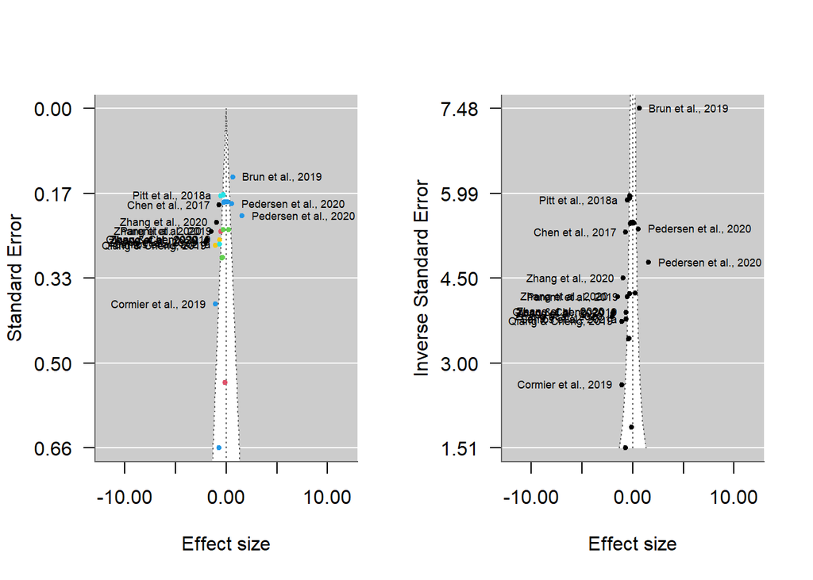

## Alluvial plot

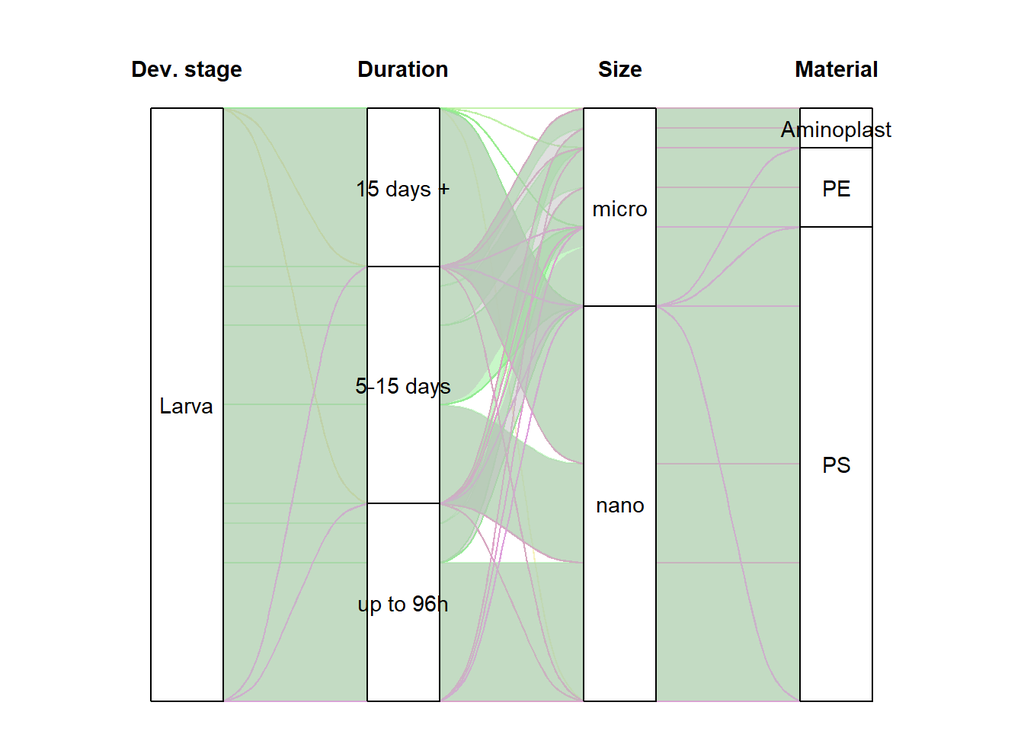

# Multilevel meta-analytic model

## Random effects formula desing

```
[1] "Considering number of studies: 14, number of ES clusters: 16 and number of independent observations of ES: 30, the random effects formula for Sensory-motor function: Distance is: ~1 | Study/EScluster/ESid"
```

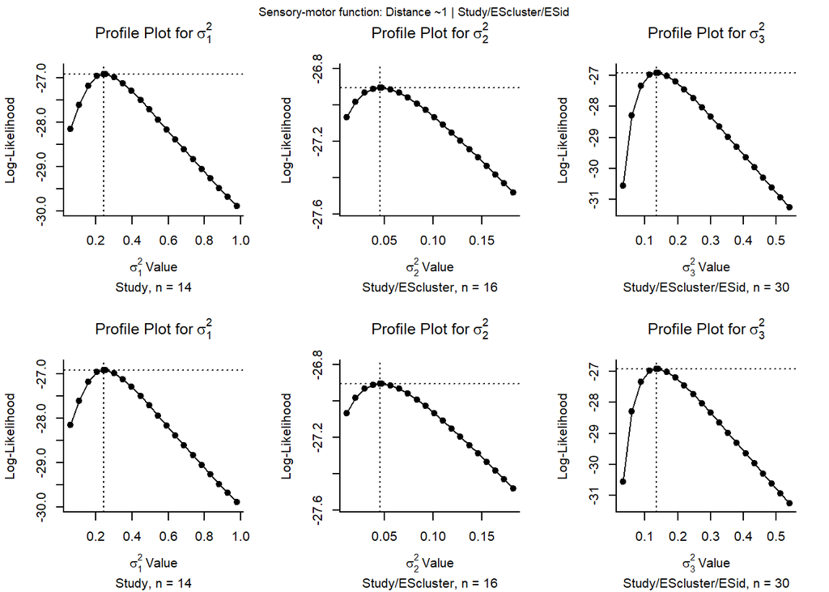

> A profile likelihood plot should show a single peak at the corresponding ML/REML estimate. If `refline=TRUE` (the default), the value of the parameter estimate is indicated by a dotted vertical line and its log-likelihood value by a dotted horizontal line. Hence, the intersection of these two lines should correspond to the peak (assuming that the model was fitted with ML/REML estimation).

> When profiling a variance component (or some other parameter that cannot be negative), the peak may be at zero (if this corresponds to the ML/REML estimate of the parameter). In this case, the profiled log-likelihood should be a monotonically decreasing function of the parameter. Similarly, when profiling a correlation component, the peak may be at -1 or +1.

> If the profiled log-likelihood has multiple peaks, this indicates that the likelihood surface is not unimodal. In such cases, the ML/REML estimate may correspond to a local optimum (when the intersection of the two dotted lines is not at the highest peak).

> If the profile is flat (over the entire parameter space or large portions of it), then this suggests that at least some of the parameters of the model are not identifiable (and the parameter estimates obtained are to some extent arbitrary). See Raue et al. (2009) for some further discussion of parameter identifiability and the use of profile likelihoods to check for this.

> The function checks whether any profiled log-likelihood value is actually larger than the log-likelihood of the fitted model (using a numerical tolerance of `lltol`). If so, a warning is issued as this might indicate that the optimizer did not identify the actual ML/REML estimate of the parameter profiled.[Viechtbauer (2022)](Viechtbauer 2010)

## Additional random effects factors

Study cluster, particle material and species as random effects term can further improve results?

|  | Nested | +StudyCluster | +Particle Material | +Species |
| --- | --- | --- | --- | --- |
| logLik: | -26.90661150249525 | -26.90661150523038 | -26.90661150449258 | -26.90661150585171 |
| deviance: | 86.52571539117686 | 86.52571539664712 | 86.52571539517152 | 86.52571539788978 |
| AIC: | 61.8132230049905 | 63.81322301046076 | 63.81322300898515 | 63.81322301170342 |
| BIC: | 67.41801253163912 | 70.81920991877153 | 70.81920991729594 | 70.8192099200142 |
| AICc: | 63.4132230049905 | 66.31322301046076 | 66.31322300898515 | 66.31322301170343 |

|  | Comparison | LRT | p_value |
| --- | --- | --- | --- |
| 1 | +Study Cluster | 0 | 1 |
| 2 | +Particle Material | 0 | 1 |
| 3 | +Species | 0 | 1 |

## Main result: Multilevel model with $\rho = 0.5$ and robust variance estimate

```r
# Assumed correlation of rho = 0.5, except if there is only one ES by Study (no
# correlation)
if (nES == nSt) {
    VCVrho <- 0
    VCV <- df$vi
} else {
    VCVrho <- 0.5
    VCV <- vcalc(vi, cluster = interaction(df$EScluster, df$Study), obs = ESid, data = df,
        rho = VCVrho)
}

mname1 <- "ML"
mname2 <- paste0(mname1, "_RobVar")

mRE[[mname1]] <- rma.mv(yi, VCV, random = RE_formula, data = df, slab = Study, method = "REML",
    test = "t", dfs = "contain", level = 95)
mRE[[mname1]] <- additional_results(mRE[[mname1]])

mRE[[mname2]] <- robust(mRE[[mname1]], cluster = df$Study, clubSandwich = TRUE)

mRE[[mname2]] <- additional_results(mRE[[mname2]])

I2_ML_RobVar <- i2_ml(mRE[[mname2]])
# I2_ML_RobVar <- i2_ml(mRE[[mname2]], boot = 1000)

extract_report(mRE[[mname2]], outcome, RE_formula)
```

#### Diagnostics plots and results

```
Multivariate Meta-Analysis Model (k = 30; method: REML)

  logLik  Deviance       AIC       BIC      AICc
-25.9679   51.9358   59.9358   65.4049   61.6024

Variance Components:

            estim    sqrt  nlvls  fixed                factor
sigma^2.1  0.2636  0.5134     14     no                 Study
sigma^2.2  0.0284  0.1685     16     no       Study/EScluster
sigma^2.3  0.1565  0.3956     30     no  Study/EScluster/ESid

Test for Heterogeneity:
Q(df = 29) = 294.3096, p-val < .0001

Number of estimates:   30
Number of clusters:    14
Estimates per cluster: 0-8 (mean: 0.51, median: 0)

Model Results:

estimate      se¹     tval¹    df¹    pval¹    ci.lb¹    ci.ub¹
 -0.4246  0.1828   -2.3235   12.1   0.0384   -0.8224   -0.0268   *

---
Signif. codes:  0 '***' 0.001 '**' 0.01 '*' 0.05 '.' 0.1 ' ' 1

1) results based on cluster-robust inference (var-cov estimator: CR2,
   approx t-test and confidence interval, df: Satterthwaite approx)
```

```
[1] 0.588 0.063 0.349
```

```
               I2_Total                I2_Study      I2_Study/EScluster
              90.791210               53.356487                5.748521
I2_Study/EScluster/ESid
              31.686202
```

```
$results
        % of total variance    I2
Level 1            9.208790   ---
Level 2           31.686202 31.69
Level 3            5.748521  5.75
Level 4           53.356487 53.36

$totalI2
[1] 90.79121

$plot
```

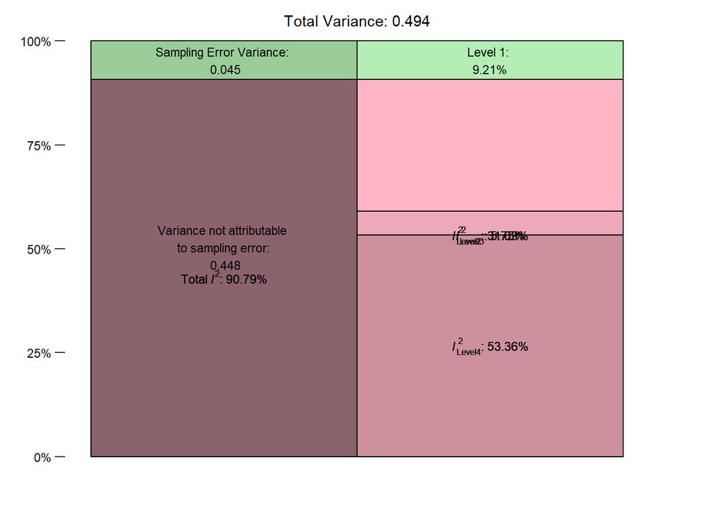

```
attr(,"class")
[1] "mlm.variance.distribution" "list"
```

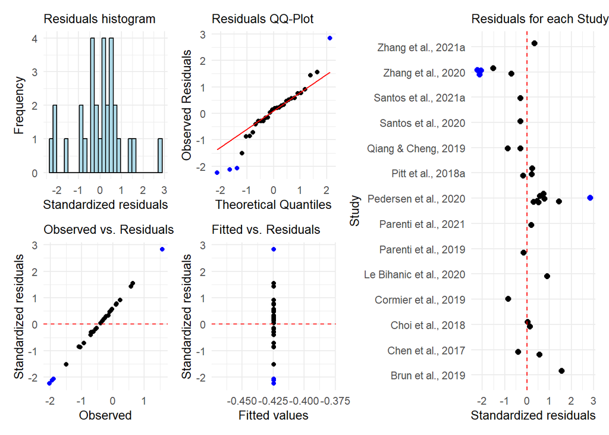

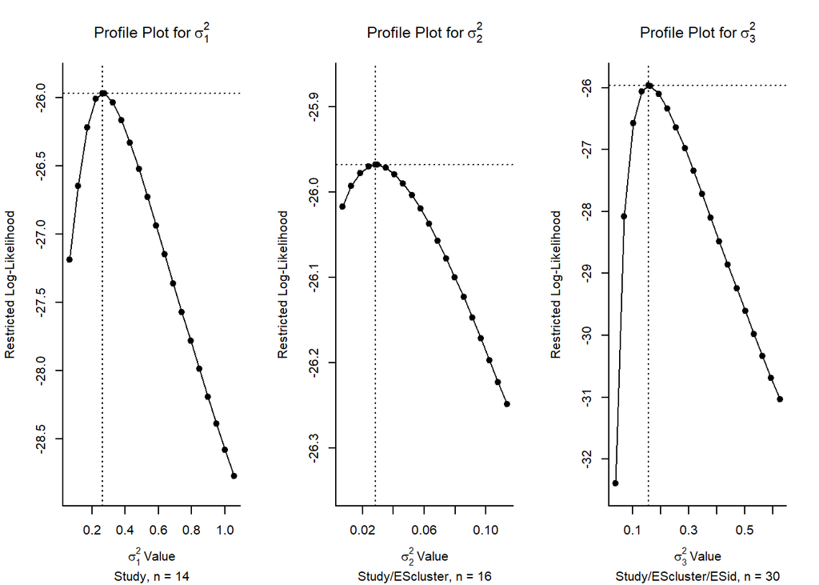

### Forest plot

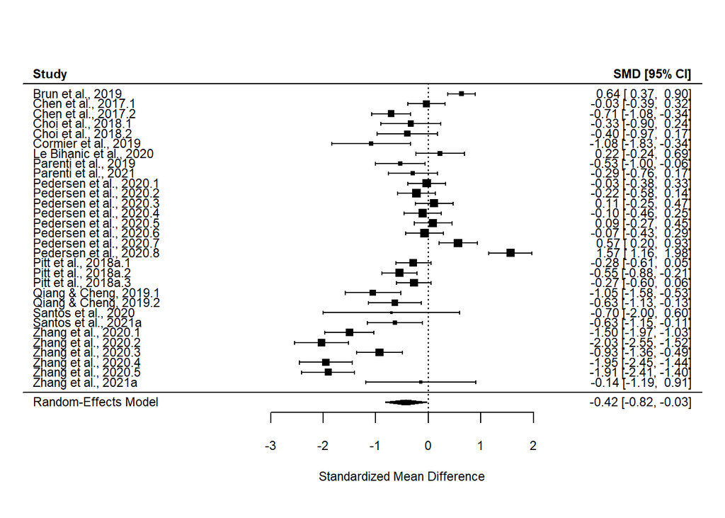

The meta-analysis comprised 30 comparisons from 16 control group clusters of 14 independent studies, so the random formula for Sensory-motor function: Distance was ~1 | Study/EScluster/ESid.

# Publication bias

> **Small-study effect:** when small studies (with small sample sizes) tend to report large effect sizes. (Yang et al. 2023)

> While the PET method works best when the true effect captured by β0β0 is **zero**, PEESE shows a better performance when the true effect is **not** zero. Stanley and Doucouliagos ([2014](https://bookdown.org/MathiasHarrer/Doing_Meta_Analysis_in_R/references.html#ref-stanley2014meta)) therefore proposed to combine both methods, in order to balance out their individual strengths. The resulting approach is the PET-PEESE method. PET-PEESE uses the intercept β0 of either PET or PEESE as the estimate of the corrected true effect.

> Whether PET or PEESE is used depends on the size of the intercept calculated by the PET method. When β0PET is significantly larger than zero in a one-sided test with α = 0.05, we use the intercept of PEESE as the true effect size estimate. If PET’s intercept is not significantly larger than zero, we remain with the PET estimate.

> In most implementations of regression models in *R*, it is conventional to test the significance of coefficients using a two-sided test (i.e. we test if a ββ weight significantly differs from zero, no matter the direction). To assume a one-sided test with α = 0.05, we already regard the intercept as significant when p < 0.1, and when the estimate of β0 is larger than zero<sup>38</sup>. (Harrer et al., n.d.)

> **Time-lag bias:** when statistically significant (“positive” results) tend to be published earlier than those with statistically non-significant findings (“negative” results), leading to a decline in reported effect sizes over time (i.e., a decline effect). (Yang et al. 2023)

> Given that high heterogeneity may invalidate publication bias test, it is best to account for the potential heterogeneity when testing publication bias. (Yang et al. 2023)

> PET-PEESE performs poorly in research areas where there are only a few studies, all studies use small samples, and where there is very high heterogeneity of results from study to study. Nonetheless, the statistical properties of conventional meta-analysis approaches are much worse than PET-PEESE under these same conditions.(Stanley 2017)

So, **better use meta-regression dataset**, but requires larger dataset to avoid possible convergence issues.

#### Plots

```
[1] "PET"
```

```
Multivariate Meta-Analysis Model (k = 30; method: REML)

  logLik  Deviance       AIC       BIC      AICc
-23.8280   47.6560   59.6560   67.4310   63.8560

Variance Components:

            estim    sqrt  nlvls  fixed                factor
sigma^2.1  0.2792  0.5283     14     no                 Study
sigma^2.2  0.0317  0.1780     16     no       Study/EScluster
sigma^2.3  0.1580  0.3975     30     no  Study/EScluster/ESid

Test for Residual Heterogeneity:
QE(df = 27) = 254.3171, p-val < .0001

Number of estimates:   30
Number of clusters:    14
Estimates per cluster: 0-8 (mean: 0.51, median: 0)

Test of Moderators (coefficients 2:3):¹
F(df1 = 2, df2 = 3.81) = 0.8043, p-val = 0.5113

Model Results:

         estimate        se¹     tval¹    df¹    pval¹      ci.lb¹     ci.ub¹
intrcpt  -65.5784  175.9471   -0.3727   5.19   0.7241   -512.8061   381.6494
ESSE      -1.5377    1.1015   -1.3960   3.04   0.2561     -5.0196     1.9442
Year       0.0325    0.0872    0.3722    5.2   0.7244     -0.1891     0.2541

intrcpt
ESSE
Year

---
Signif. codes:  0 '***' 0.001 '**' 0.01 '*' 0.05 '.' 0.1 ' ' 1

1) results based on cluster-robust inference (var-cov estimator: CR2,
   approx t/F-tests and confidence intervals, df: Satterthwaite approx)
```

```
  pred   se ci.lb ci.ub pi.lb pi.ub
 -0.02 0.35 -0.90  0.86 -1.95  1.91
```

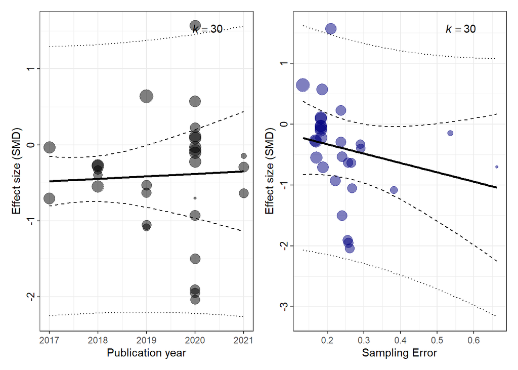

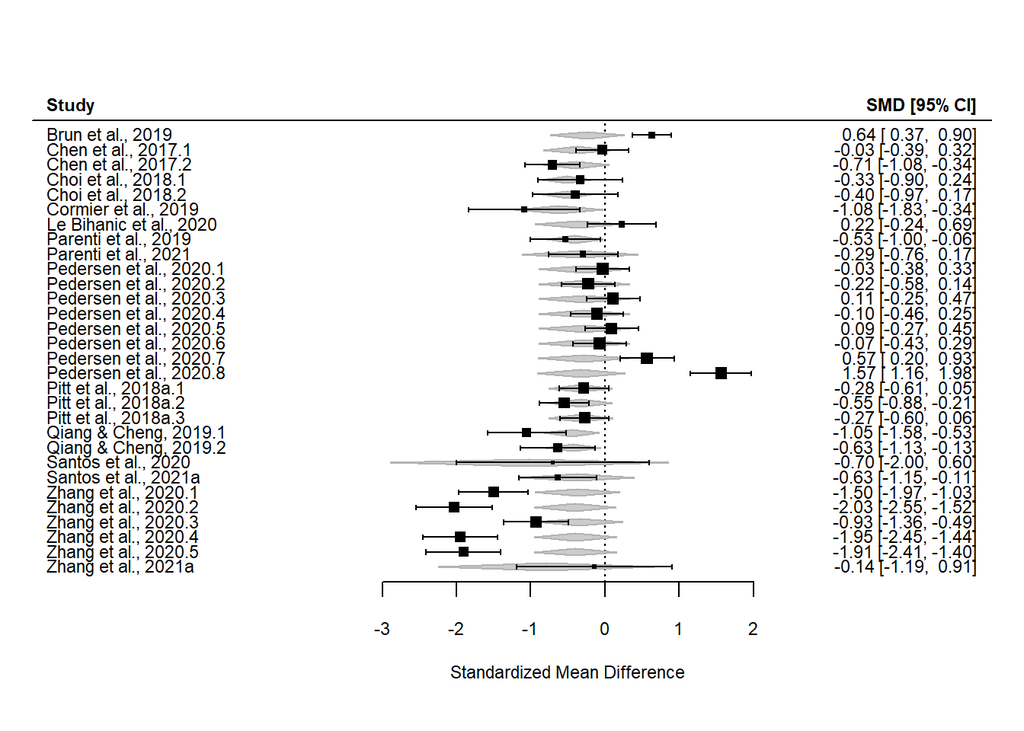

**Small-study effect** The regression slope of the extended Egger’s regression is $\sqrt{SMDSE} = -1.5377185$ is it statistically different from zero?`

If p<0.050: Smaller studies (with larger sampling error) have larger effect sizes –> small-study effect exists in this dataset. Data is assymmetrically distributed in the funnel plot.

If p>=0.050 no small-study effect exists in this dataset. Smaller studies (with larger sampling error) do not have larger effect sizes –> no small-study effect exists in this dataset. Data is symmetrically distributed in the funnel plot.

If p<0.050: studies with statistically significant findings tend to be published earlier than these with “negative” results, i.e. time-lag bias exists in this dataset

If p>=0.050: studies with statistically significant findings **do not** tend to be published earlier than these with “negative” results, i.e. no time-lag bias exists in this dataset

### Sensitivity analysis: publication bias with adapted SE

> Egger’s regression and its variants suffer from low power and poor performance when there are fewer than 20 effect sizes, or when the overall effect is large. (Nakagawa et al. 2022)

> Instead of the sample size (n1 + n2), however, for a meta-analysis of SMD or lnRR, we propose using the ‘effective sample size’ because it accounts for unbalanced sampling (cf. Stanley, 2005).(Nakagawa et al. 2022)

```r
if (mRE[[bias]]$pval[2] < 0.05) {

    # calculate modified SE based on effective sample size
    df$ess_vi <- with(df, sqrt((n_treat + n_ctrl)/(n_treat * n_ctrl)))
    df$ess_SE <- sqrt(df$ess_vi)  ## sampling error for ES

    # PET + year
    bias2 <- "PET sensitivity"
    mRE[[bias2]] <- rma.mv(yi, VCV, random = RE_formula, mods = ~ess_SE + Year, data = df,
        slab = Study, method = "REML", test = "t", dfs = "contain", level = 95)
    mRE[[bias2]] <- robust(mRE[[bias2]], cluster = df$Study, clubSandwich = TRUE)
    mRE[[bias2]] <- additional_results(mRE[[bias2]])
    mRE[[bias2]][["pi"]] <- predict(mRE[[bias2]], newmods = c(0, mean(df$Year)),
        digits = 2)

    # PEESE + year
    if (mRE[[bias2]]$pval[2] < 0.1) {
        mname <- "PEESE sensitivity"
        mRE[[mname]] <- rma.mv(yi, VCV, random = RE_formula, mods = ~ess_vi + Year,
            data = df, slab = Study, method = "REML", test = "t", dfs = "contain",
            level = 95)
        mRE[[mname]] <- robust(mRE[[mname]], cluster = df$Study, clubSandwich = TRUE)
        mRE[[mname]] <- additional_results(mRE[[mname]])
        mRE[[mname]][["pi"]] <- predict(mRE[[mname]], newmods = c(0, mean(df$Year)),
            digits = 2)
        bias2 <- mname
    }
}
```

If the results are the same, indicates the robustness of the small-study test.

# Sensitivity

## Rho range

```r
if (VCVrho != 0) {

    rho_range <- c(0, 0.25, 0.75, 0.9)  # assume a range values of rho

    for (j in 1:length(rho_range)) {

        mname <- paste("rho", rho_range[j], sep = "_")

        VCV2 <- vcalc(vi, cluster = interaction(df$EScluster, df$Study), obs = ESid,
            data = df, rho = rho_range[j])

        mRE[[mname]] <- rma.mv(yi, VCV2, random = RE_formula, data = df, slab = Study,
            method = "REML", test = "t", dfs = "contain", level = 95)
        mRE[[mname]] <- robust(mRE[[mname]], cluster = df$Study, clubSandwich = TRUE)
        mRE[[mname]] <- additional_results(mRE[[mname]])
    }
}
```

## Leave one out + Rho range

```r
if (VCVrho != 0) {
    rho_range <- c(0.25, 0.5, 0.75, 0.9)
} else {
    rho_range <- 0
}

for (i in sort(unique(df$Study))) {

    df_temp <- df[df$Study != i, ]

    for (j in 1:length(rho_range)) {

        mname <- paste("rho", rho_range[j], "l1o", i, sep = "_")
        print(mname)
        VCV2 <- vcalc(vi, cluster = interaction(df_temp$EScluster, df_temp$Study),
            obs = ESid, data = df_temp, rho = rho_range[j])

        mRE[[mname]] <- rma.mv(yi, VCV2, random = RE_formula, data = df_temp, slab = Study,
            method = "REML", test = "t", dfs = "contain", level = 95)
        mRE[[mname]] <- robust(mRE[[mname]], cluster = df_temp$Study, clubSandwich = TRUE)
        mRE[[mname]] <- additional_results(mRE[[mname]])
    }
}
```

```
[1] "rho_0.25_l1o_Brun et al., 2019"
[1] "rho_0.5_l1o_Brun et al., 2019"
[1] "rho_0.75_l1o_Brun et al., 2019"
[1] "rho_0.9_l1o_Brun et al., 2019"
[1] "rho_0.25_l1o_Chen et al., 2017"
[1] "rho_0.5_l1o_Chen et al., 2017"
[1] "rho_0.75_l1o_Chen et al., 2017"
[1] "rho_0.9_l1o_Chen et al., 2017"
[1] "rho_0.25_l1o_Choi et al., 2018"
[1] "rho_0.5_l1o_Choi et al., 2018"
[1] "rho_0.75_l1o_Choi et al., 2018"
[1] "rho_0.9_l1o_Choi et al., 2018"
[1] "rho_0.25_l1o_Cormier et al., 2019"
[1] "rho_0.5_l1o_Cormier et al., 2019"
[1] "rho_0.75_l1o_Cormier et al., 2019"
```

[output cut: 41 more lines]

# Tables

|  | n studies | n ES clusters | n ES | overall effect | standard error | p-value | Lower CI | Upper CI | Lower PI | Upper PI | Q | Q p-value | $I^2$$_{total}$ | $I^2$$_{Study}$ | $I^2$$_{EScluster}$ | $I^2$$_{ES}$ | $\sigma^2$$_{Study}$ | $\sigma^2$$_{EScluster}$ | $\sigma^2$$_{ES}$ |
| --- | --- | --- | --- | --- | --- | --- | --- | --- | --- | --- | --- | --- | --- | --- | --- | --- | --- | --- | --- |
| ML | 14 | 16 | 30 | -0.42 | 0.2 | 0.0358 | -0.82 | -0.03 | -1.92 | 1.07 | 294.31 | 0 | 90.79 | 53.36 | 5.75 | 31.69 | 0.26 | 0.03 | 0.16 |
| ML_RobVar | 14 | 16 | 30 | -0.42 | 0.2 | 0.0384 | -0.82 | -0.03 | -1.94 | 1.09 | 294.31 | 0 | 90.79 | 53.36 | 5.75 | 31.69 | 0.26 | 0.03 | 0.16 |
| PET | 14 | 16 | 30 | -65.58 | 175.9 | 0.7241 | -512.81 | 381.65 | -1.95 | 1.91 | 254.32 | 0 | 91.16 | 54.27 | 6.16 | 30.72 | 0.28 | 0.03 | 0.16 |
| rho_0 | 14 | 16 | 30 | -0.43 | 0.2 | 0.0382 | -0.82 | -0.03 | -1.94 | 1.09 | 352.02 | 0 | 90.85 | 53.78 | 9.70 | 27.36 | 0.27 | 0.05 | 0.14 |
| rho_0.25 | 14 | 16 | 30 | -0.43 | 0.2 | 0.0383 | -0.82 | -0.03 | -1.94 | 1.09 | 295.64 | 0 | 90.82 | 53.57 | 7.73 | 29.52 | 0.27 | 0.04 | 0.15 |
| rho_0.75 | 14 | 16 | 30 | -0.42 | 0.2 | 0.0384 | -0.82 | -0.03 | -1.93 | 1.08 | 378.90 | 0 | 90.76 | 53.13 | 3.76 | 33.87 | 0.26 | 0.02 | 0.17 |
| rho_0.9 | 14 | 16 | 30 | -0.42 | 0.2 | 0.0385 | -0.82 | -0.03 | -1.93 | 1.08 | 691.39 | 0 | 90.75 | 52.99 | 2.56 | 35.20 | 0.26 | 0.01 | 0.17 |
| rho_0.25_l1o_Brun et al., 2019 | 13 | 15 | 29 | -0.51 | 0.2 | 0.0172 | -0.90 | -0.11 | -1.96 | 0.95 | 243.02 | 0 | 89.37 | 50.53 | 7.52 | 31.32 | 0.23 | 0.03 | 0.14 |
| rho_0.5_l1o_Brun et al., 2019 | 13 | 15 | 29 | -0.50 | 0.2 | 0.0173 | -0.90 | -0.11 | -1.96 | 0.95 | 240.61 | 0 | 89.34 | 50.30 | 5.34 | 33.70 | 0.23 | 0.02 | 0.15 |
| rho_0.75_l1o_Brun et al., 2019 | 13 | 15 | 29 | -0.50 | 0.2 | 0.0173 | -0.90 | -0.11 | -1.95 | 0.94 | 324.24 | 0 | 89.30 | 50.06 | 3.14 | 36.10 | 0.22 | 0.01 | 0.16 |
| rho_0.9_l1o_Brun et al., 2019 | 13 | 15 | 29 | -0.50 | 0.2 | 0.0174 | -0.90 | -0.11 | -1.95 | 0.94 | 633.57 | 0 | 89.28 | 49.91 | 1.82 | 37.55 | 0.22 | 0.01 | 0.17 |
| rho_0.25_l1o_Chen et al., 2017 | 13 | 15 | 28 | -0.43 | 0.2 | 0.0521 | -0.86 | 0.00 | -2.01 | 1.15 | 286.52 | 0 | 91.17 | 55.82 | 8.27 | 27.08 | 0.29 | 0.04 | 0.14 |
| rho_0.5_l1o_Chen et al., 2017 | 13 | 15 | 28 | -0.43 | 0.2 | 0.0523 | -0.86 | 0.01 | -2.01 | 1.15 | 280.89 | 0 | 91.15 | 55.61 | 6.38 | 29.15 | 0.29 | 0.03 | 0.15 |
| rho_0.75_l1o_Chen et al., 2017 | 13 | 15 | 28 | -0.43 | 0.2 | 0.0525 | -0.86 | 0.01 | -2.01 | 1.15 | 352.47 | 0 | 91.12 | 55.39 | 4.50 | 31.24 | 0.29 | 0.02 | 0.16 |
| rho_0.9_l1o_Chen et al., 2017 | 13 | 15 | 28 | -0.43 | 0.2 | 0.0525 | -0.86 | 0.01 | -2.01 | 1.15 | 625.80 | 0 | 91.11 | 55.26 | 3.36 | 32.49 | 0.29 | 0.02 | 0.17 |
| rho_0.25_l1o_Choi et al., 2018 | 13 | 15 | 28 | -0.43 | 0.2 | 0.0515 | -0.87 | 0.00 | -2.03 | 1.16 | 295.45 | 0 | 91.72 | 54.71 | 7.43 | 29.58 | 0.29 | 0.04 | 0.16 |
| rho_0.5_l1o_Choi et al., 2018 | 13 | 15 | 28 | -0.43 | 0.2 | 0.0514 | -0.86 | 0.00 | -2.02 | 1.16 | 294.12 | 0 | 91.70 | 54.45 | 5.55 | 31.70 | 0.29 | 0.03 | 0.17 |
| rho_0.75_l1o_Choi et al., 2018 | 13 | 15 | 28 | -0.43 | 0.2 | 0.0514 | -0.86 | 0.00 | -2.02 | 1.16 | 378.67 | 0 | 91.68 | 54.17 | 3.67 | 33.84 | 0.29 | 0.02 | 0.18 |
| rho_0.9_l1o_Choi et al., 2018 | 13 | 15 | 28 | -0.43 | 0.2 | 0.0514 | -0.86 | 0.00 | -2.02 | 1.16 | 691.05 | 0 | 91.67 | 54.00 | 2.53 | 35.14 | 0.29 | 0.01 | 0.19 |
| rho_0.25_l1o_Cormier et al., 2019 | 13 | 15 | 29 | -0.39 | 0.2 | 0.0660 | -0.80 | 0.03 | -1.93 | 1.15 | 291.08 | 0 | 91.13 | 54.21 | 7.69 | 29.23 | 0.27 | 0.04 | 0.15 |
| rho_0.5_l1o_Cormier et al., 2019 | 13 | 15 | 29 | -0.39 | 0.2 | 0.0661 | -0.80 | 0.03 | -1.92 | 1.15 | 289.70 | 0 | 91.10 | 53.98 | 5.73 | 31.39 | 0.27 | 0.03 | 0.16 |
| rho_0.75_l1o_Cormier et al., 2019 | 13 | 15 | 29 | -0.38 | 0.2 | 0.0663 | -0.80 | 0.03 | -1.92 | 1.15 | 374.26 | 0 | 91.07 | 53.75 | 3.75 | 33.56 | 0.27 | 0.02 | 0.17 |
| rho_0.9_l1o_Cormier et al., 2019 | 13 | 15 | 29 | -0.38 | 0.2 | 0.0663 | -0.80 | 0.03 | -1.92 | 1.15 | 686.97 | 0 | 91.05 | 53.61 | 2.57 | 34.88 | 0.27 | 0.01 | 0.17 |
| rho_0.25_l1o_Le Bihanic et al., 2020 | 13 | 15 | 29 | -0.47 | 0.2 | 0.0305 | -0.89 | -0.05 | -2.01 | 1.07 | 291.00 | 0 | 90.93 | 53.63 | 7.85 | 29.45 | 0.27 | 0.04 | 0.15 |
| rho_0.5_l1o_Le Bihanic et al., 2020 | 13 | 15 | 29 | -0.47 | 0.2 | 0.0306 | -0.89 | -0.05 | -2.01 | 1.07 | 289.69 | 0 | 90.90 | 53.42 | 5.88 | 31.60 | 0.27 | 0.03 | 0.16 |
| rho_0.75_l1o_Le Bihanic et al., 2020 | 13 | 15 | 29 | -0.47 | 0.2 | 0.0307 | -0.89 | -0.05 | -2.00 | 1.06 | 374.30 | 0 | 90.88 | 53.21 | 3.90 | 33.77 | 0.26 | 0.02 | 0.17 |
| rho_0.9_l1o_Le Bihanic et al., 2020 | 13 | 15 | 29 | -0.47 | 0.2 | 0.0307 | -0.89 | -0.05 | -2.00 | 1.06 | 686.37 | 0 | 90.86 | 53.08 | 2.70 | 35.08 | 0.26 | 0.01 | 0.17 |
| rho_0.25_l1o_Parenti et al., 2019 | 13 | 15 | 29 | -0.42 | 0.2 | 0.0547 | -0.85 | 0.01 | -1.99 | 1.16 | 294.47 | 0 | 91.36 | 55.09 | 7.85 | 28.42 | 0.29 | 0.04 | 0.15 |
| rho_0.5_l1o_Parenti et al., 2019 | 13 | 15 | 29 | -0.42 | 0.2 | 0.0548 | -0.84 | 0.01 | -1.99 | 1.16 | 293.09 | 0 | 91.33 | 54.88 | 5.97 | 30.48 | 0.29 | 0.03 | 0.16 |
| rho_0.75_l1o_Parenti et al., 2019 | 13 | 15 | 29 | -0.42 | 0.2 | 0.0550 | -0.84 | 0.01 | -1.99 | 1.16 | 377.66 | 0 | 91.31 | 54.67 | 4.08 | 32.55 | 0.28 | 0.02 | 0.17 |
| rho_0.9_l1o_Parenti et al., 2019 | 13 | 15 | 29 | -0.42 | 0.2 | 0.0550 | -0.84 | 0.01 | -1.99 | 1.15 | 690.33 | 0 | 91.29 | 54.54 | 2.95 | 33.80 | 0.28 | 0.02 | 0.18 |
| rho_0.25_l1o_Parenti et al., 2021 | 13 | 15 | 29 | -0.43 | 0.2 | 0.0470 | -0.86 | -0.01 | -2.01 | 1.14 | 295.63 | 0 | 91.35 | 55.00 | 7.89 | 28.46 | 0.29 | 0.04 | 0.15 |
| rho_0.5_l1o_Parenti et al., 2021 | 13 | 15 | 29 | -0.43 | 0.2 | 0.0471 | -0.86 | -0.01 | -2.01 | 1.14 | 294.30 | 0 | 91.32 | 54.80 | 6.01 | 30.52 | 0.29 | 0.03 | 0.16 |
| rho_0.75_l1o_Parenti et al., 2021 | 13 | 15 | 29 | -0.43 | 0.2 | 0.0472 | -0.86 | -0.01 | -2.00 | 1.14 | 378.89 | 0 | 91.30 | 54.59 | 4.12 | 32.59 | 0.28 | 0.02 | 0.17 |
| rho_0.9_l1o_Parenti et al., 2021 | 13 | 15 | 29 | -0.43 | 0.2 | 0.0473 | -0.86 | -0.01 | -2.00 | 1.14 | 691.39 | 0 | 91.28 | 54.46 | 2.98 | 33.84 | 0.28 | 0.02 | 0.18 |
| rho_0.25_l1o_Pedersen et al., 2020 | 13 | 14 | 22 | -0.48 | 0.2 | 0.0201 | -0.87 | -0.09 | -1.86 | 0.89 | 194.01 | 0 | 87.49 | 67.05 | 0.00 | 20.44 | 0.28 | 0.00 | 0.08 |
| rho_0.5_l1o_Pedersen et al., 2020 | 13 | 14 | 22 | -0.48 | 0.2 | 0.0204 | -0.88 | -0.09 | -1.87 | 0.90 | 186.20 | 0 | 87.60 | 65.08 | 0.00 | 22.52 | 0.27 | 0.00 | 0.09 |
| rho_0.75_l1o_Pedersen et al., 2020 | 13 | 14 | 22 | -0.48 | 0.2 | 0.0207 | -0.88 | -0.09 | -1.87 | 0.90 | 206.36 | 0 | 87.72 | 62.88 | 0.00 | 24.84 | 0.26 | 0.00 | 0.10 |
| rho_0.9_l1o_Pedersen et al., 2020 | 13 | 14 | 22 | -0.49 | 0.2 | 0.0208 | -0.88 | -0.09 | -1.88 | 0.91 | 300.02 | 0 | 87.79 | 61.50 | 0.00 | 26.29 | 0.26 | 0.00 | 0.11 |
| rho_0.25_l1o_Pitt et al., 2018a | 13 | 15 | 27 | -0.43 | 0.2 | 0.0540 | -0.87 | 0.01 | -2.05 | 1.18 | 292.71 | 0 | 91.14 | 53.51 | 6.69 | 30.95 | 0.29 | 0.04 | 0.17 |
| rho_0.5_l1o_Pitt et al., 2018a | 13 | 15 | 27 | -0.43 | 0.2 | 0.0542 | -0.87 | 0.01 | -2.05 | 1.18 | 290.39 | 0 | 91.12 | 53.36 | 4.94 | 32.82 | 0.29 | 0.03 | 0.18 |
| rho_0.75_l1o_Pitt et al., 2018a | 13 | 15 | 27 | -0.43 | 0.2 | 0.0545 | -0.87 | 0.01 | -2.04 | 1.18 | 371.71 | 0 | 91.10 | 53.20 | 3.19 | 34.70 | 0.29 | 0.02 | 0.19 |
| rho_0.9_l1o_Pitt et al., 2018a | 13 | 15 | 27 | -0.43 | 0.2 | 0.0546 | -0.87 | 0.01 | -2.04 | 1.18 | 674.24 | 0 | 91.08 | 53.11 | 2.13 | 35.84 | 0.29 | 0.01 | 0.20 |
| rho_0.25_l1o_Qiang & Cheng, 2019 | 13 | 15 | 28 | -0.39 | 0.2 | 0.0702 | -0.82 | 0.04 | -1.96 | 1.18 | 286.42 | 0 | 91.40 | 54.41 | 7.45 | 29.54 | 0.28 | 0.04 | 0.15 |
| rho_0.5_l1o_Qiang & Cheng, 2019 | 13 | 15 | 28 | -0.39 | 0.2 | 0.0701 | -0.82 | 0.04 | -1.96 | 1.18 | 285.54 | 0 | 91.37 | 54.18 | 5.55 | 31.64 | 0.28 | 0.03 | 0.16 |
| rho_0.75_l1o_Qiang & Cheng, 2019 | 13 | 15 | 28 | -0.39 | 0.2 | 0.0700 | -0.82 | 0.04 | -1.95 | 1.17 | 368.78 | 0 | 91.34 | 53.95 | 3.64 | 33.75 | 0.28 | 0.02 | 0.17 |
| rho_0.9_l1o_Qiang & Cheng, 2019 | 13 | 15 | 28 | -0.39 | 0.2 | 0.0700 | -0.82 | 0.04 | -1.95 | 1.17 | 675.27 | 0 | 91.33 | 53.81 | 2.49 | 35.02 | 0.28 | 0.01 | 0.18 |
| rho_0.25_l1o_Santos et al., 2020 | 13 | 15 | 29 | -0.41 | 0.2 | 0.0503 | -0.83 | 0.00 | -1.97 | 1.14 | 295.22 | 0 | 91.34 | 54.56 | 7.81 | 28.97 | 0.28 | 0.04 | 0.15 |
| rho_0.5_l1o_Santos et al., 2020 | 13 | 15 | 29 | -0.41 | 0.2 | 0.0504 | -0.83 | 0.00 | -1.96 | 1.13 | 293.89 | 0 | 91.31 | 54.35 | 5.88 | 31.09 | 0.28 | 0.03 | 0.16 |
| rho_0.75_l1o_Santos et al., 2020 | 13 | 15 | 29 | -0.41 | 0.2 | 0.0505 | -0.83 | 0.00 | -1.96 | 1.13 | 378.48 | 0 | 91.28 | 54.13 | 3.94 | 33.22 | 0.27 | 0.02 | 0.17 |
| rho_0.9_l1o_Santos et al., 2020 | 13 | 15 | 29 | -0.41 | 0.2 | 0.0506 | -0.83 | 0.00 | -1.96 | 1.13 | 691.00 | 0 | 91.27 | 53.99 | 2.77 | 34.51 | 0.27 | 0.01 | 0.17 |
| rho_0.25_l1o_Santos et al., 2021a | 13 | 15 | 29 | -0.41 | 0.2 | 0.0575 | -0.84 | 0.02 | -1.98 | 1.16 | 293.76 | 0 | 91.36 | 55.02 | 7.83 | 28.51 | 0.29 | 0.04 | 0.15 |
| rho_0.5_l1o_Santos et al., 2021a | 13 | 15 | 29 | -0.41 | 0.2 | 0.0576 | -0.84 | 0.02 | -1.98 | 1.16 | 292.38 | 0 | 91.33 | 54.81 | 5.94 | 30.58 | 0.28 | 0.03 | 0.16 |
| rho_0.75_l1o_Santos et al., 2021a | 13 | 15 | 29 | -0.41 | 0.2 | 0.0577 | -0.84 | 0.02 | -1.98 | 1.16 | 376.94 | 0 | 91.30 | 54.59 | 4.04 | 32.67 | 0.28 | 0.02 | 0.17 |
| rho_0.9_l1o_Santos et al., 2021a | 13 | 15 | 29 | -0.41 | 0.2 | 0.0578 | -0.83 | 0.02 | -1.98 | 1.16 | 689.64 | 0 | 91.29 | 54.46 | 2.90 | 33.93 | 0.28 | 0.01 | 0.18 |
| rho_0.25_l1o_Zhang et al., 2020 | 13 | 14 | 25 | -0.25 | 0.1 | 0.1140 | -0.57 | 0.07 | -1.44 | 0.94 | 156.67 | 0 | 85.69 | 19.55 | 18.00 | 48.15 | 0.06 | 0.05 | 0.15 |
| rho_0.5_l1o_Zhang et al., 2020 | 13 | 14 | 25 | -0.25 | 0.1 | 0.1149 | -0.57 | 0.07 | -1.43 | 0.94 | 177.26 | 0 | 85.63 | 19.49 | 14.68 | 51.47 | 0.06 | 0.04 | 0.16 |
| rho_0.75_l1o_Zhang et al., 2020 | 13 | 14 | 25 | -0.25 | 0.1 | 0.1158 | -0.57 | 0.07 | -1.43 | 0.93 | 265.69 | 0 | 85.57 | 19.43 | 11.34 | 54.80 | 0.06 | 0.03 | 0.16 |
| rho_0.9_l1o_Zhang et al., 2020 | 13 | 14 | 25 | -0.25 | 0.1 | 0.1162 | -0.57 | 0.07 | -1.43 | 0.93 | 546.62 | 0 | 85.54 | 19.40 | 9.33 | 56.80 | 0.06 | 0.03 | 0.17 |
| rho_0.25_l1o_Zhang et al., 2021a | 13 | 15 | 29 | -0.44 | 0.2 | 0.0413 | -0.86 | -0.02 | -2.00 | 1.12 | 295.58 | 0 | 91.37 | 54.59 | 7.87 | 28.91 | 0.28 | 0.04 | 0.15 |
| rho_0.5_l1o_Zhang et al., 2021a | 13 | 15 | 29 | -0.44 | 0.2 | 0.0414 | -0.86 | -0.02 | -1.99 | 1.12 | 294.25 | 0 | 91.34 | 54.38 | 5.95 | 31.01 | 0.28 | 0.03 | 0.16 |
| rho_0.75_l1o_Zhang et al., 2021a | 13 | 15 | 29 | -0.44 | 0.2 | 0.0415 | -0.85 | -0.02 | -1.99 | 1.11 | 378.85 | 0 | 91.31 | 54.16 | 4.02 | 33.13 | 0.28 | 0.02 | 0.17 |
| rho_0.9_l1o_Zhang et al., 2021a | 13 | 15 | 29 | -0.44 | 0.2 | 0.0416 | -0.85 | -0.02 | -1.99 | 1.11 | 691.31 | 0 | 91.30 | 54.03 | 2.86 | 34.41 | 0.27 | 0.01 | 0.17 |

|  | ML | ML_RobVar | PET | rho_0 | rho_0.25 | rho_0.75 | rho_0.9 | rho_0.25_l1o_Brun.et.al...2019 | rho_0.5_l1o_Brun.et.al...2019 | rho_0.75_l1o_Brun.et.al...2019 | rho_0.9_l1o_Brun.et.al...2019 | rho_0.25_l1o_Chen.et.al...2017 | rho_0.5_l1o_Chen.et.al...2017 | rho_0.75_l1o_Chen.et.al...2017 | rho_0.9_l1o_Chen.et.al...2017 | rho_0.25_l1o_Choi.et.al...2018 | rho_0.5_l1o_Choi.et.al...2018 | rho_0.75_l1o_Choi.et.al...2018 | rho_0.9_l1o_Choi.et.al...2018 | rho_0.25_l1o_Cormier.et.al...2019 | rho_0.5_l1o_Cormier.et.al...2019 | rho_0.75_l1o_Cormier.et.al...2019 | rho_0.9_l1o_Cormier.et.al...2019 | rho_0.25_l1o_Le.Bihanic.et.al...2020 | rho_0.5_l1o_Le.Bihanic.et.al...2020 | rho_0.75_l1o_Le.Bihanic.et.al...2020 | rho_0.9_l1o_Le.Bihanic.et.al...2020 | rho_0.25_l1o_Parenti.et.al...2019 | rho_0.5_l1o_Parenti.et.al...2019 | … |
| --- | --- | --- | --- | --- | --- | --- | --- | --- | --- | --- | --- | --- | --- | --- | --- | --- | --- | --- | --- | --- | --- | --- | --- | --- | --- | --- | --- | --- | --- | --- |
| logLik: | -25.96787551057612 | -25.96787551057612 | -23.82799362070985 | -26.00763134332843 | -25.98838657350266 | -25.94602674173953 | -25.93224099075415 | -24.09029919914885 | -24.06872880151226 | -24.04582984431993 | -24.03141786576665 | -24.45173913446149 | -24.43566846499856 | -24.41822027584646 | -24.40705732891504 | -24.96079611859446 | -24.96174235791367 | -24.96262942962466 | -24.96315052203422 | -24.92978826344193 | -24.9087564990008 | -24.8863739789481 | -24.87226136616498 | -24.94616079695479 | -24.92674950276985 | -24.90602047373678 | -24.89291672545294 | -25.36731518406521 | -25.34806986662998 | … |
| deviance: | 51.93575102115224 | 51.93575102115224 | 47.65598724141971 | 52.01526268665687 | 51.97677314700532 | 51.89205348347907 | 51.86448198150831 | 48.1805983982977 | 48.13745760302452 | 48.09165968863986 | 48.0628357315333 | 48.90347826892298 | 48.87133692999711 | 48.83644055169292 | 48.81411465783008 | 49.92159223718891 | 49.92348471582734 | 49.92525885924933 | 49.92630104406844 | 49.85957652688386 | 49.8175129980016 | 49.77274795789621 | 49.74452273232997 | 49.89232159390958 | 49.8534990055397 | 49.81204094747356 | 49.78583345090588 | 50.73463036813042 | 50.69613973325997 | … |
| AIC: | 59.93575102115224 | 59.93575102115224 | 59.65598724141971 | 60.01526268665687 | 59.97677314700532 | 59.89205348347907 | 59.86448198150831 | 56.1805983982977 | 56.13745760302452 | 56.09165968863986 | 56.0628357315333 | 56.90347826892298 | 56.87133692999711 | 56.83644055169292 | 56.81411465783008 | 57.92159223718891 | 57.92348471582734 | 57.92525885924933 | 57.92630104406844 | 57.85957652688386 | 57.8175129980016 | 57.77274795789621 | 57.74452273232997 | 57.89232159390958 | 57.8534990055397 | 57.81204094747356 | 57.78583345090588 | 58.73463036813042 | 58.69613973325997 | … |
| BIC: | 65.40493434109813 | 65.40493434109813 | 67.43100843744568 | 65.48444600660277 | 65.44595646695122 | 65.36123680342496 | 65.3336653014542 | 61.50941643899852 | 61.46627564372533 | 61.42047772934067 | 61.39165377223411 | 62.0868257329403 | 62.05468439401443 | 62.01978801571023 | 61.9974621218474 | 63.10493970120623 | 63.10683217984466 | 63.10860632326664 | 63.10964850808575 | 63.18839456758468 | 63.14633103870242 | 63.10156599859702 | 63.07334077303079 | 63.2211396346104 | 63.18231704624051 | 63.14085898817438 | 63.11465149160669 | 64.06344840883123 | 64.02495777396078 | … |
| AICc: | 61.6024176878189 | 61.6024176878189 | 63.85598724141971 | 61.68192935332353 | 61.64343981367198 | 61.55872015014573 | 61.53114864817497 | 57.91972883308031 | 57.87658803780712 | 57.83079012342247 | 57.80196616631591 | 58.7216600871048 | 58.68951874817893 | 58.65462236987474 | 58.6322964760119 | 59.73977405537073 | 59.74166653400916 | 59.74344067743115 | 59.74448286225026 | 59.59870696166647 | 59.55664343278421 | 59.51187839267882 | 59.48365316711258 | 59.63145202869219 | 59.59262944032231 | 59.55117138225617 | 59.52496388568849 | 60.47376080291303 | 60.43527016804258 | … |

# Influential cases

> Outliers and influential cases can actually reveal patterns that may lead to new insights about study characteristics that could be acting as potential moderators (Viechtbauer and Cheung 2010)

Cook’s distance: examine what effect the deletion of the ith study has on the fitted values of all k studies simultaneously (Viechtbauer and Cheung 2010)

DFBETAS: directly examine the influence of deleting the ith case on each individual parameter estimate (Viechtbauer and Cheung 2010)

So if a point has high Cook’s Distance, use DFBETAS to identify witch estimate is mainly influenced (only makes sense for meta regression).

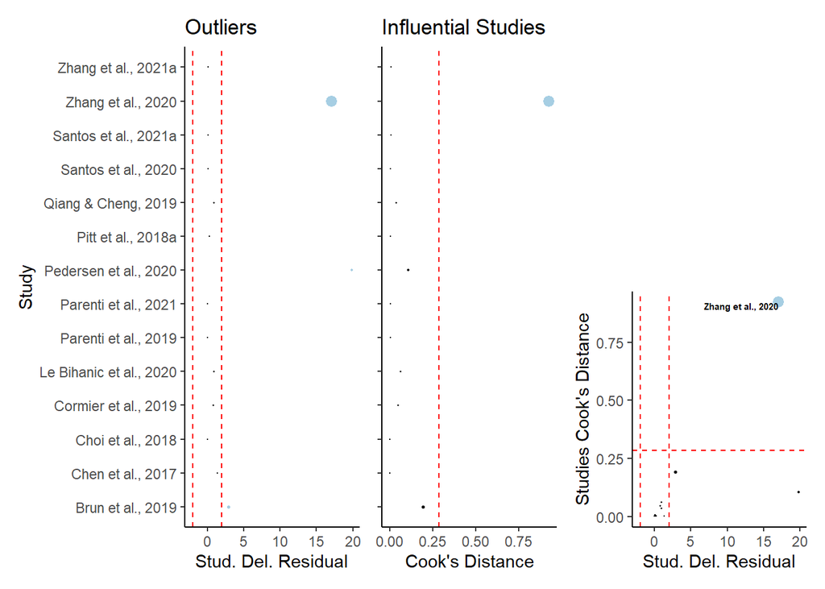

```r
influentialcases_plots(mRE, "ML_RobVar", "ML", 3)
```

# Multilevel meta-regression

SYRCLE PROTOCOL: Meta-regression will be used for outcomes with at least 10 experiments.

> The minimal number of studies or effect sizes required by a multilevel meta-regression remains unknown, albeit some simulation studies suggest that the estimates of model coefficients of a multilevel meta-regression are generally stable under various simulated situations.(Yang et al. 2023) … the complexity of parameterization of such a meta-regression requires a large dataset to make optimization algorithms free of convergence issues.(Yang et al. 2023)

## Model 1: Size, Duration, Development

```r
df_MR <- select(df, c("Year", "StudyID", "Study", "EScluster", "ESid", "DevelopmentalStage",
    "ExposureDurationDays", "ParticleSizeMean", "yi", "vi"))

mname1 <- "Base"
mname2 <- paste0(mname1, "_RobVar")

# are there differences between the different forms of DevelopmentalStage?
# mods_formula <- formula(~ ParticleSizeMean +
# ExposureDurationDays*DevelopmentalStage) at least one of the
# DevelopmentalStage levels is different than zero?
if (n_outcome != 10) {
    mods_formula <- formula(~0 + ParticleSizeMean + ExposureDurationDays * DevelopmentalStage)
} else if (n_outcome == 10) {
    # for Sensory-motor function
    mods_formula <- formula(~0 + ParticleSizeMean + ExposureDurationDays)
}

mMR[[mname1]] <- rma.mv(yi, VCV, random = RE_formula, mods = mods_formula, data = df_MR,
    slab = Study, method = "REML", test = "t", dfs = "contain", level = 95)  #it will only keep complete cases

nSt_MR <- mMR[[mname1]]$s.nlevels[1]  # number of studies
nEC_MR <- mMR[[mname1]]$s.nlevels[2]  # number of ESclusters
nES_MR <- mMR[[mname1]]$s.nlevels[3]  # number of independent ES

print(paste0("Number of studies: ", nSt_MR, ", number of ES clusters: ", nEC_MR,
    " and number of independent observations of ES: ", nES_MR))
```

```
[1] "Number of studies: 14, number of ES clusters: 16 and number of independent observations of ES: 30"
```

```r
mMR[[mname2]] <- robust(mMR[[mname1]], cluster = df_MR$Study, clubSandwich = TRUE,
    verbose = TRUE)

mMR[[mname2]][["i2"]] <- i2_ml(mMR[[mname2]])
mMR[[mname2]][["icc"]] <- round(mMR[[mname2]]$sigma2/sum(mMR[[mname2]]$sigma2), 3)

if (n_outcome != 10) {
    anova(mMR[[mname2]], btt = c("DevelopmentalStage", "ExposureDurationDays", "ParticleSizeMean"))
} else if (n_outcome == 10) {
    # for Sensory-motor function
    anova(mMR[[mname2]], btt = c("ExposureDurationDays", "ParticleSizeMean"))
}
```

```
                  spec coefs   Fval df1  df2   pval
1 ExposureDurationDays     2 0.0001   1 1.05 0.9928
2     ParticleSizeMean     1 0.0796   1 1.02 0.8241
```

The meta-regression comprised 30 comparisons from 16 control group clusters of 14 independent studies.

#### Diagnostics plots

```
Multivariate Meta-Analysis Model (k = 30; method: REML)

  logLik  Deviance       AIC       BIC      AICc
-26.7966   53.5932   63.5932   70.2542   66.3205

Variance Components:

            estim    sqrt  nlvls  fixed                factor
sigma^2.1  0.4576  0.6765     14     no                 Study
sigma^2.2  0.0364  0.1908     16     no       Study/EScluster
sigma^2.3  0.1609  0.4011     30     no  Study/EScluster/ESid

Test for Residual Heterogeneity:
QE(df = 28) = 322.9087, p-val < .0001

Number of estimates:   30
Number of clusters:    14
Estimates per cluster: 0-8 (mean: 0.51, median: 0)

Test of Moderators (coefficients 1:2):¹
F(df1 = 2, df2 = 0.55) = 0.0142, p-val = 0.9862

Model Results:

                      estimate      se¹     tval¹    df¹    pval¹    ci.lb¹
ParticleSizeMean       -0.0009  0.0033   -0.2822   1.02   0.8241   -0.0413
ExposureDurationDays    0.0001  0.0109    0.0112   1.05   0.9928   -0.1240
                       ci.ub¹
ParticleSizeMean      0.0394
ExposureDurationDays  0.1243

---
Signif. codes:  0 '***' 0.001 '**' 0.01 '*' 0.05 '.' 0.1 ' ' 1

1) results based on cluster-robust inference (var-cov estimator: CR2,
   approx t/F-tests and confidence intervals, df: Satterthwaite approx)
```

|  | ML | REML |
| --- | --- | --- |
| ll | -29.39143 | -26.79660 |
| dev | 96.35869 | 53.59321 |
| AIC | 68.78287 | 63.59321 |
| BIC | 75.78886 | 70.25423 |
| AICc | 71.28287 | 66.32048 |

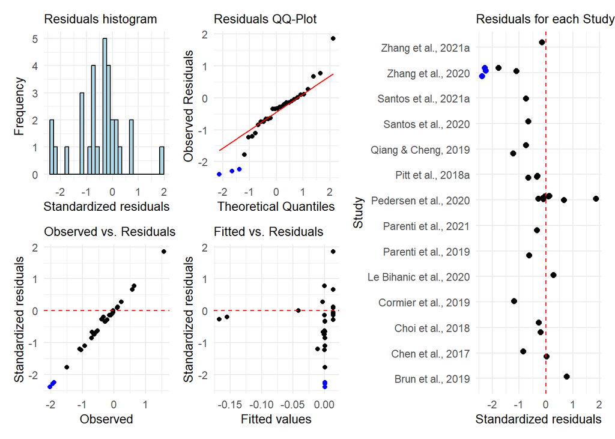

#### Influential cases

```
      Brun et al., 2019       Chen et al., 2017       Choi et al., 2018
           2.357062e-04            2.500354e-01            6.498954e+00
   Cormier et al., 2019 Le Bihanic et al., 2020    Parenti et al., 2019
           7.329651e-03            6.731195e-04            4.507908e-04
   Parenti et al., 2021   Pedersen et al., 2020      Pitt et al., 2018a
           8.822720e-04            2.994444e+01            8.246126e-04
    Qiang & Cheng, 2019     Santos et al., 2020    Santos et al., 2021a
           8.210583e-04            5.507293e-04            2.545436e-03
     Zhang et al., 2020     Zhang et al., 2021a
           9.791614e-02            5.759637e-04
```

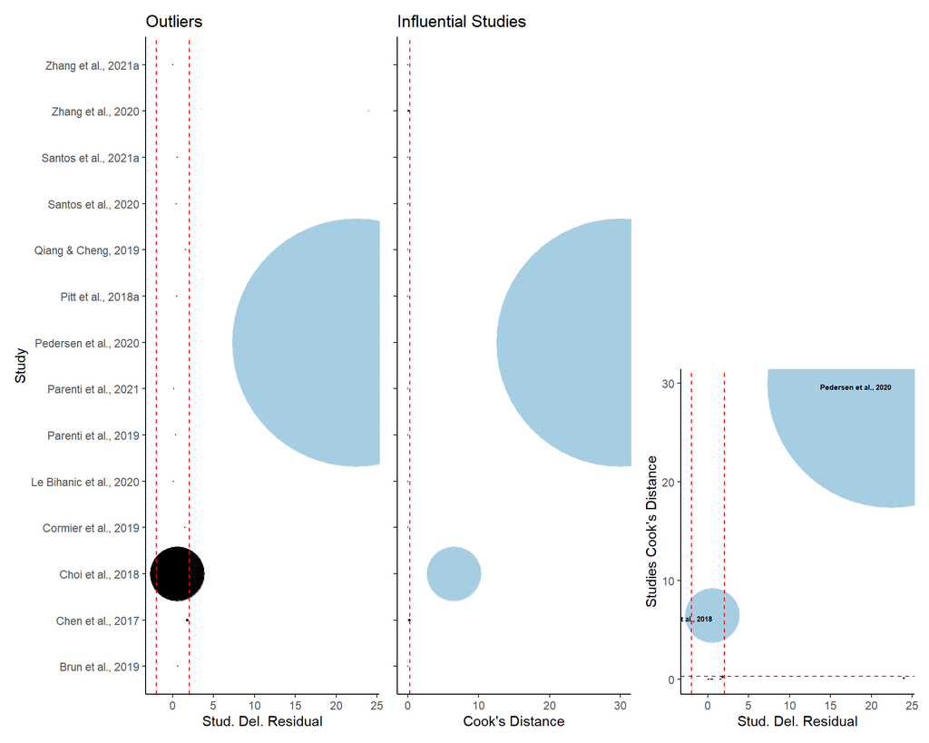

#### Orchard plots

(Nakagawa et al. 2021)

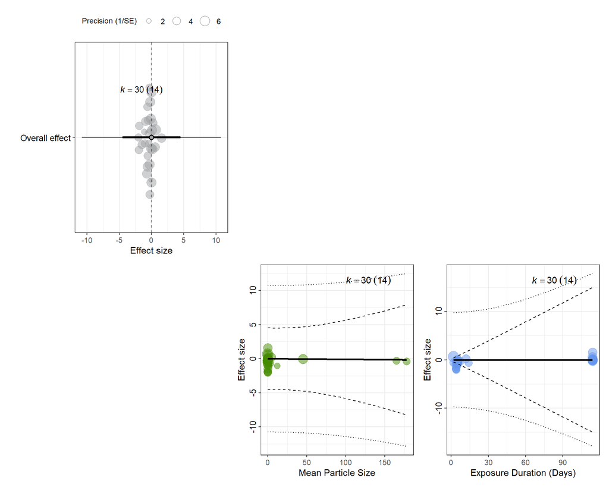

## Model 2: + Concentration

```r
df_MR <- select(df, c("Year", "StudyID", "Study", "EScluster", "ESid", "DevelopmentalStage",
    "ExposureDurationDays", "ParticleSizeMean", "Concentration_mg_L", "yi", "vi"))

mname1 <- "Conc+"
mname2 <- paste0(mname1, "_RobVar")

if (n_outcome != 10) {
    mods_formula <- formula(~0 + ParticleSizeMean + Concentration_mg_L + ExposureDurationDays *
        DevelopmentalStage)
} else if (n_outcome == 10) {
    # for Sensory-motor function for Sensory-motor function
    mods_formula <- formula(~0 + ParticleSizeMean + Concentration_mg_L + ExposureDurationDays)
}

mMR[[mname1]] <- rma.mv(yi, VCV, random = RE_formula, mods = mods_formula, data = df_MR,
    slab = Study, method = "REML", test = "t", dfs = "contain", level = 95)  #it will only keep complete cases

nSt_MR <- mMR[[mname1]]$s.nlevels[1]  # number of studies
nEC_MR <- mMR[[mname1]]$s.nlevels[2]  # number of ESclusters
nES_MR <- mMR[[mname1]]$s.nlevels[3]  # number of independent ES

print(paste0("Number of studies: ", nSt_MR, ", number of ES clusters: ", nEC_MR,
    " and number of independent observations of ES: ", nES_MR))
```

```
[1] "Number of studies: 14, number of ES clusters: 16 and number of independent observations of ES: 30"
```

```r
mMR[[mname2]] <- robust(mMR[[mname1]], cluster = df_MR$Study, clubSandwich = TRUE,
    verbose = TRUE)

mMR[[mname2]][["i2"]] <- i2_ml(mMR[[mname2]])
mMR[[mname2]][["icc"]] <- round(mMR[[mname2]]$sigma2/sum(mMR[[mname2]]$sigma2), 3)

if (n_outcome != 10) {
    anova(mMR[[mname2]], btt = c("DevelopmentalStage", "ExposureDurationDays", "ParticleSizeMean",
        "Concentration_mg_L"))
} else if (n_outcome == 10) {
    # for Sensory-motor function
    anova(mMR[[mname2]], btt = c("ExposureDurationDays", "ParticleSizeMean", "Concentration_mg_L"))
}
```

```
                  spec coefs   Fval df1  df2   pval
1 ExposureDurationDays     3 0.0000   1 1.05 0.9984
2     ParticleSizeMean     1 0.0569   1 1.02 0.8503
3   Concentration_mg_L     2 2.7385   1 1.00 0.3460
```

The meta-regression comprised 30 comparisons from 16 control group clusters of 14 independent studies.

#### Diagnostics plots

```
Multivariate Meta-Analysis Model (k = 30; method: REML)

  logLik  Deviance       AIC       BIC      AICc
-26.0763   52.1526   64.1526   71.9277   68.3526

Variance Components:

            estim    sqrt  nlvls  fixed                factor
sigma^2.1  0.5111  0.7149     14     no                 Study
sigma^2.2  0.0361  0.1900     16     no       Study/EScluster
sigma^2.3  0.1575  0.3969     30     no  Study/EScluster/ESid

Test for Residual Heterogeneity:
QE(df = 27) = 314.2072, p-val < .0001

Number of estimates:   30
Number of clusters:    14
Estimates per cluster: 0-8 (mean: 0.51, median: 0)

Test of Moderators (coefficients 1:3):¹
F(df1 = 3, df2 = 0.05) = 0.0207, p-val = 0.9892

Model Results:

                      estimate      se¹     tval¹    df¹    pval¹    ci.lb¹
ParticleSizeMean       -0.0009  0.0037   -0.2385   1.02   0.8503   -0.0451
Concentration_mg_L      0.0001  0.0000    1.6548      1   0.3460   -0.0005
ExposureDurationDays    0.0000  0.0113    0.0025   1.05   0.9984   -0.1279
                       ci.ub¹
ParticleSizeMean      0.0433
Concentration_mg_L    0.0007
ExposureDurationDays  0.1279

---
Signif. codes:  0 '***' 0.001 '**' 0.01 '*' 0.05 '.' 0.1 ' ' 1

1) results based on cluster-robust inference (var-cov estimator: CR2,
   approx t/F-tests and confidence intervals, df: Satterthwaite approx)
```

|  | ML | REML |
| --- | --- | --- |
| ll | -29.25866 | -26.07632 |
| dev | 96.09313 | 52.15264 |
| AIC | 70.51731 | 64.15264 |
| BIC | 78.92450 | 71.92766 |
| AICc | 74.16949 | 68.35264 |

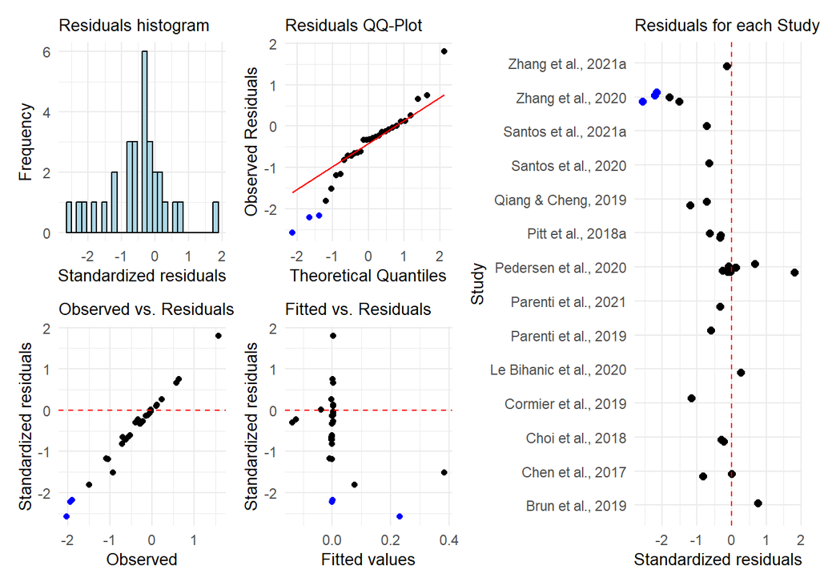

#### Influential cases

```
      Brun et al., 2019       Chen et al., 2017       Choi et al., 2018
           2.549128e-03            2.904791e-01            6.090914e+00
   Cormier et al., 2019 Le Bihanic et al., 2020    Parenti et al., 2019
           7.196620e-03            1.106456e-02            5.259539e-03
   Parenti et al., 2021   Pedersen et al., 2020      Pitt et al., 2018a
           1.003956e-02            3.073843e+01            2.491538e-03
    Qiang & Cheng, 2019     Santos et al., 2020    Santos et al., 2021a
           3.561024e-03            2.299410e-03            4.985625e-03
     Zhang et al., 2020     Zhang et al., 2021a
           2.003492e+03            7.287913e-03
```

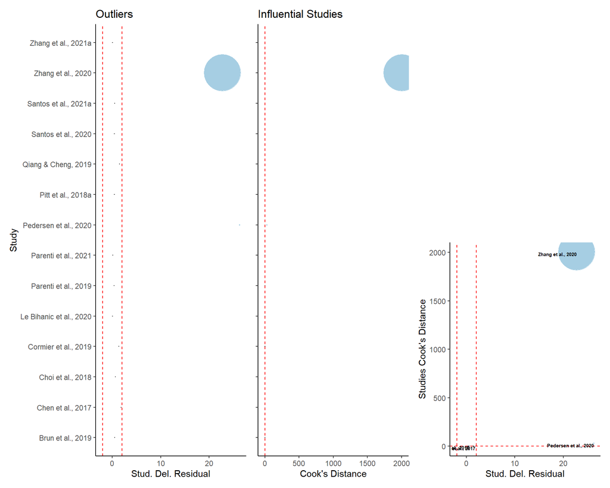

#### Orchard plots

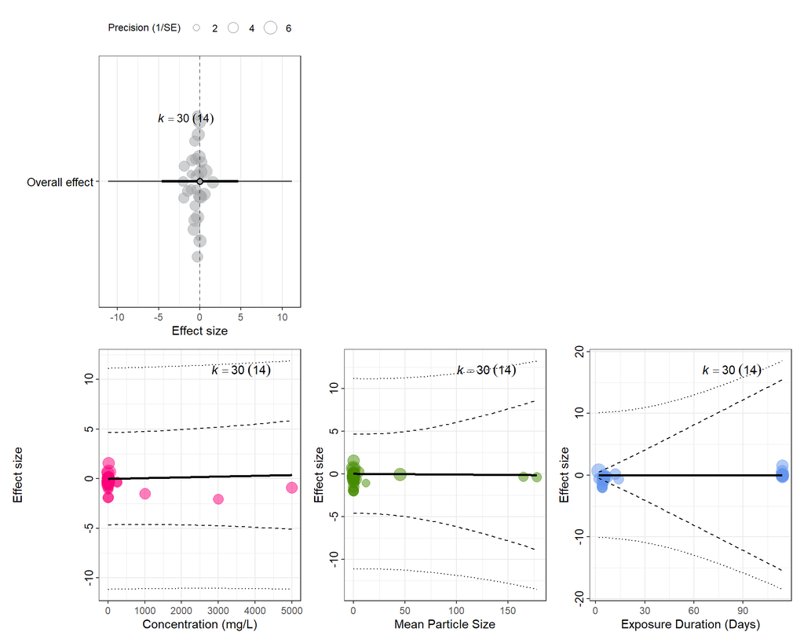

## Model 3: + ParticleMaterial

```r
df_MR <- select(df, c("Year", "StudyID", "Study", "EScluster", "ESid", "DevelopmentalStage",
    "ExposureDurationDays", "ParticleSizeMean", "ParticleMaterial", "yi", "vi"))

mname1 <- "PartMat+"
mname2 <- paste0(mname1, "_RobVar")

if (n_outcome != 10) {
    mods_formula <- formula(~(ParticleSizeMean + ExposureDurationDays * DevelopmentalStage +
        ParticleMaterial))
} else if (n_outcome == 10) {
    # for Sensory-motor function
    mods_formula <- formula(~(ParticleSizeMean + ExposureDurationDays + ParticleMaterial))
}

mMR[[mname1]] <- rma.mv(yi, VCV, random = RE_formula, mods = mods_formula, data = df_MR,
    slab = Study, method = "REML", test = "t", dfs = "contain", level = 95)  #it will only keep complete cases

nSt_MR <- mMR[[mname1]]$s.nlevels[1]  # number of studies
nEC_MR <- mMR[[mname1]]$s.nlevels[2]  # number of ESclusters
nES_MR <- mMR[[mname1]]$s.nlevels[3]  # number of independent ES

print(paste0("Number of studies: ", nSt_MR, ", number of ES clusters: ", nEC_MR,
    " and number of independent observations of ES: ", nES_MR))
```

```
[1] "Number of studies: 14, number of ES clusters: 16 and number of independent observations of ES: 30"
```

```r
mMR[[mname2]] <- robust(mMR[[mname1]], cluster = df_MR$Study, clubSandwich = TRUE,
    verbose = TRUE)

mMR[[mname2]][["i2"]] <- i2_ml(mMR[[mname2]])
mMR[[mname2]][["icc"]] <- round(mMR[[mname2]]$sigma2/sum(mMR[[mname2]]$sigma2), 3)

if (n_outcome != 10) {
    anova(mMR[[mname2]], btt = c("DevelopmentalStage", "ExposureDurationDays", "ParticleSizeMean",
        "ParticleMaterial"))
} else if (n_outcome == 10) {
    # for Sensory-motor function
    anova(mMR[[mname2]], btt = c("ExposureDurationDays", "ParticleSizeMean", "ParticleMaterial"))
}
```

```
                  spec coefs   Fval df1  df2   pval
1 ExposureDurationDays     3 4.1473   1 1.37 0.2345
2     ParticleSizeMean     2 0.2011   1 1.74 0.7034
3     ParticleMaterial   4:5 0.1558   2 1.19 0.8708
```

The meta-regression comprised 30 comparisons from 16 control group clusters of 14 independent studies.

#### Diagnostics plots

```
Multivariate Meta-Analysis Model (k = 30; method: REML)

  logLik  Deviance       AIC       BIC      AICc
-21.4810   42.9621   58.9621   68.7131   67.9621

Variance Components:

            estim    sqrt  nlvls  fixed                factor
sigma^2.1  0.3134  0.5598     14     no                 Study
sigma^2.2  0.0403  0.2007     16     no       Study/EScluster
sigma^2.3  0.1606  0.4007     30     no  Study/EScluster/ESid

Test for Residual Heterogeneity:
QE(df = 25) = 271.4136, p-val < .0001

Number of estimates:   30
Number of clusters:    14
Estimates per cluster: 0-8 (mean: 0.51, median: 0)

Test of Moderators (coefficients 2:5):¹
F(df1 = 4, df2 = 0.24) = 0.2510, p-val = 0.9003

Model Results:

                      estimate      se¹      tval¹    df¹    pval¹    ci.lb¹
intrcpt                -0.7387  0.0398   -18.5557   1.01   0.0329   -1.2276
ParticleSizeMean        0.0023  0.0052     0.4484   1.74   0.7034   -0.0235
ExposureDurationDays    0.0071  0.0035     2.0365   1.37   0.2345   -0.0170
ParticleMaterialPE      0.1501  0.6444     0.2330   2.18   0.8358   -2.4119
ParticleMaterialPS      0.1808  0.2499     0.7237   1.34   0.5746   -1.6081
                        ci.ub¹
intrcpt               -0.2498   *
ParticleSizeMean       0.0282
ExposureDurationDays   0.0312
ParticleMaterialPE     2.7121
ParticleMaterialPS     1.9697

---
Signif. codes:  0 '***' 0.001 '**' 0.01 '*' 0.05 '.' 0.1 ' ' 1

1) results based on cluster-robust inference (var-cov estimator: CR2,
   approx t/F-tests and confidence intervals, df: Satterthwaite approx)
```

|  | ML | REML |
| --- | --- | --- |
| ll | -26.14424 | -21.48105 |
| dev | 89.86430 | 42.96209 |
| AIC | 68.28849 | 58.96209 |
| BIC | 79.49807 | 68.71310 |
| AICc | 75.14563 | 67.96209 |

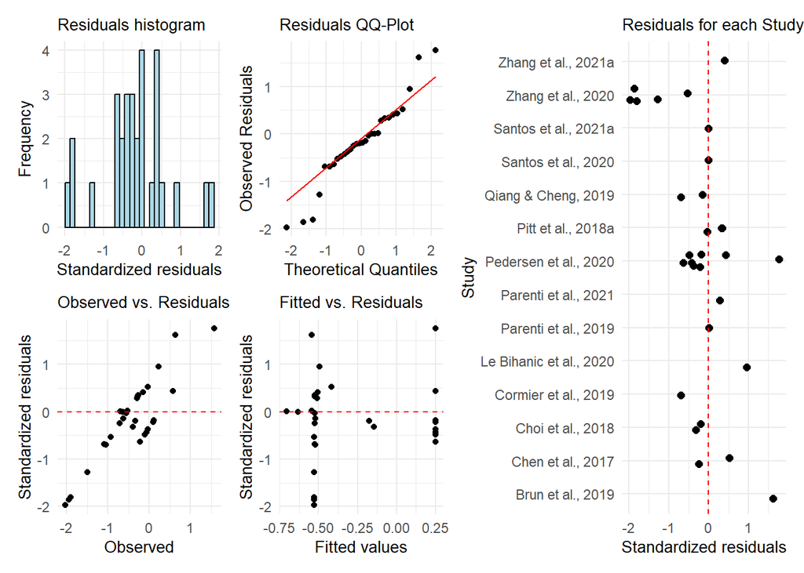

#### Influential cases

```
      Brun et al., 2019       Chen et al., 2017       Choi et al., 2018
           6.671264e-01            2.092438e-01            8.649924e+00
   Cormier et al., 2019 Le Bihanic et al., 2020    Parenti et al., 2019
           4.436502e-01            1.474950e+00            1.513866e-03
   Parenti et al., 2021   Pedersen et al., 2020      Pitt et al., 2018a
           8.336396e-03            4.583987e+02            1.204677e-02
    Qiang & Cheng, 2019     Santos et al., 2020    Santos et al., 2021a
           4.070953e-02            5.033768e-01            1.338358e+00
     Zhang et al., 2020     Zhang et al., 2021a
           2.168392e+00            1.245012e-02
```

[figure not shown]

#### Orchard plots

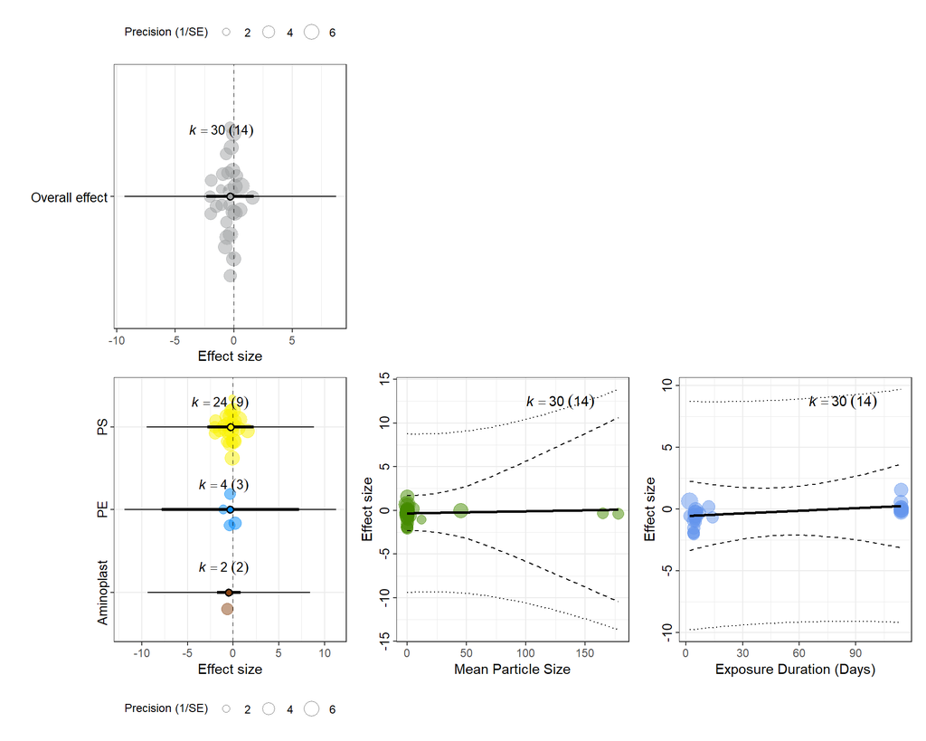

# Referências

Harrer, Mathias, Pim Cuijpers, Toshi A. Furukawa, and David D. Ebert. n.d. *Chapter 9 Publication Bias | Doing Meta-Analysis in R*. https://bookdown.org/MathiasHarrer/Doing_Meta_Analysis_in_R/pub-bias.html.

Nakagawa, Shinichi, Malgorzata Lagisz, Michael D. Jennions, Julia Koricheva, Daniel W. A. Noble, Timothy H. Parker, Alfredo Sánchez-Tójar, Yefeng Yang, and Rose E. O’Dea. 2022. “Methods for Testing Publication Bias in Ecological and Evolutionary Meta-Analyses.” *Methods in Ecology and Evolution* 13 (1): 4–21. https://doi.org/10.1111/2041-210X.13724.

Nakagawa, Shinichi, Malgorzata Lagisz, Rose E. O’Dea, Joanna Rutkowska, Yefeng Yang, Daniel W. A. Noble, and Alistair M. Senior. 2021. “The Orchard Plot: Cultivating a Forest Plot for Use in Ecology, Evolution, and Beyond.” *Research Synthesis Methods* 12 (1): 4–12. https://doi.org/10.1002/jrsm.1424.

Stanley, T. D. 2017. “Limitations of PET-PEESE and Other Meta-Analysis Methods.” *Social Psychological and Personality Science* 8 (5): 581–91. https://doi.org/10.1177/1948550617693062.

Viechtbauer, Wolfgang. 2010. “Conducting Meta-Analyses in R with the Metafor Package.” *Journal of Statistical Software* 36 (August): 1–48. https://doi.org/10.18637/jss.v036.i03.

———. 2022. “Konstantopoulos (2011) [the Metafor Package].” https://www.metafor-project.org/doku.php/analyses:konstantopoulos2011.

Viechtbauer, Wolfgang, and Mike W.-L. Cheung. 2010. “Outlier and Influence Diagnostics for Meta-Analysis.” *Research Synthesis Methods* 1 (2): 112–25. https://doi.org/10.1002/jrsm.11.

Yang, Yefeng, Malcolm Macleod, Jinming Pan, Malgorzata Lagisz, and Shinichi Nakagawa. 2023. “Advanced Methods and Implementations for the Meta-Analyses of Animal Models: Current Practices and Future Recommendations.” *Neuroscience & Biobehavioral Reviews* 146 (March): 105016. https://doi.org/10.1016/j.neubiorev.2022.105016.